# 模型评估与优化

作者：欧新宇（Xinyu OU）

本文档所展示的测试结果，均运行于：Intel Core i7-7700K CPU 4.2GHz

**本章要点**：

1. 使用交叉验证对模型进行评估
2. 使用网格搜索寻找模型的最优参数
3. 对分类模型的可行度进行评估

回顾我们之前对一个模型进行性能评估的过程：

1. 载入数据集
2. 使用train_test_split将数据集拆分成`训练集`（train set）和`测试集`（test set）
3. 使用训练集（train set）训练模型
4. 使用训练好的模型在测试集上进行测试并输出评分
5. 反复调整`超参数`并迭代地训练模型以获得最优模型

在这个过程中，我们使用模型在测试集上的输出结果作为评判超参数优劣的指标。但是，在实际应用中，这种方法是错误的。通常情况下，测试集是不可见的，换句话说，测试集不应该出现在训练的所有过程中，只能作为最后的评测，并且只能被执行一次，或者不能根据测试集的测评结果来调整模型。

那问题是，我们依据什么来调节超参数呢？

> 训练集？No！

下面，我们将介绍更好地获得最优模型的方法：`交叉验证法`和`网格搜索法`。

## 1. 使用交叉验证进行模型评估

**交叉验证（Cross Validation）**，有的时候也称作**循环估计（Rotation Estimation）**，是一种统计学上将数据样本切割成较小子集的实用方法，该理论由Seymour Geisser提出的。主要用于建模应用中，在给定的建模样本中，拿出大部分样本进行建模型，留小部分样本用刚建立的模型进行预测，并求这小部分样本的预测误差，记录它们的平方加和PRESS(predicted Error Sum of Squares)。这个过程一直进行，直到所有的样本都被预报了一次而且仅被预报一次。

在使用训练集对参数进行训练的时候，通常会将数据集为三个部分：训练集（train set），验证集（validation set），测试集（test set）。这样的划分是为了保证训练效果而特意设置的。

- **训练集**：用于训练模型的数据样本。
- **验证集**：在模型训练过程中，单独留出的样本集，用于调整模型的超参数和用于对模型的能力进行初步评估。

  > 在神经网络中， 我们用验证数据集去寻找最优的网络深度，或者决定反向传播算法的停止点或者在神经网络中选择隐藏层神经元的数量。 在普通的机器学习中常用的交叉验证（Cross Validation) 就是把训练数据集本身再细分成不同的验证数据集去训练模型。
- **测试集**：用来评估模型最终的泛化能力，更多的时候用来对比不同算法的性能。但不能作为调参、选择特征等算法相关的选择的依据。

在引入了验证集之后，我们可以考虑将前面的模型评估过程进行一定的修正：

1. 载入数据集(dataset)
2. 将数据集拆分成`训练集`(train set)、`测试集`(test set)和`验证集`(validation set)
3. 使用训练集训练模型(model)
4. 在训练过程中反复使用`验证集`获取模型的*评分(score)、误差(error)*和*损失(loss)*（损失函数的值）等信息
5. 根据从`验证集`中获得的结论调整*超参数*(hyperparameter)
6. 反复**迭代训练**，并调整超参数直到`收敛`(convergence)
7. 使用训练好(已收敛)的模型所获得的**超参数不变**，在 `训练集`+`验证集` 上再次进行训练，直到收敛，获得最终的模型final_model
8. 使用最终的模型final_model在测试集上输出评分

在实际的训练中，训练的结果对于`训练集`的拟合程度通常还是挺好的（初始条件敏感），但是对于`训练集`之外的数据的拟合程度通常就不那么令人满意了。因此我们通常并不会把所有的数据集都拿来训练，而是分出一部分来（这一部分不参加训练）对`训练集`生成的参数进行测试，相对客观的判断这些参数对`训练集`之外的数据的符合程度。这种思想就称为**交叉验证**（Cross Validation）

常见的交叉验证有以下几种：

- 留出法（holdout cross validation）
- k折交叉验证（k-fold cross validation）
- 留一法（leave one out cross validation）
- 随机采样（ShuffleSplit）
- 分层采样法（stratification）

### 1.1 留出法（Holdout）

在机器学习任务中，拿到数据后，我们首先会将原始数据集分为三部分：`训练集`、`验证集`和`测试集`。训练集用于训练模型，验证集用于模型的参数选择配置，测试集对于模型来说是未知数据，用于评估模型的泛化能力。

[figure not shown]

如上图所示，原始的数据集被划分为三部分，我们会在`训练集`上做训练，在`验证集`上做参数调整，并最终在`测试集`上输出**最终的性能评估**。

- 留出法的**优点**：
  - 处理简单，只需随机把原始数据分为三组即可。
- 留出法的**缺点**：
  - 只做一次分割，没有达到交叉的思想，由于是随机的将原始数据分组，所以最后验证集分类准确率的高低与原始数据的分组有很大的关系，得到的结果并不具有说服性。换句话说，划分出来作为验证集的样本，可能会存在类别不均衡的问题。
  - 数据集被分成三个集合后，用于训练的数据更少了。

由于Holdout留出法只对模型进行一次划分，所以我们可以使用基础数据集划分工具（train_test_split）来实现数据集的拆分。但是，由于train_test_split只能实现train-test的二类划分，不能实现train-val-test的三类划分，因此，我们需要进行两次划分来实现该功能。

假设，我们在Wine数据集上按照 $7:1:2$ 的比例来进行划分训练集、验证机和测试集（比例并不绝对），我们可以得到以下代码：

```python
from sklearn import datasets
from sklearn.model_selection import train_test_split
from sklearn.svm import SVC

# TODO: 1.载入数据集
# 载入wine数据集
wine = datasets.load_wine()

# TODO: 2.拆分数据集：按照 7:1:2 的比例来进行划分训练集、验证机和测试集
X_trainval, X_test, y_trainval, y_test = train_test_split(wine.data, wine.target, train_size=0.8, random_state=10)
X_train, X_val, y_train, y_val = train_test_split(X_trainval, y_trainval, train_size=0.875,  random_state=10)

# 观察数据集形态
print("原始数据集形态{}".format(wine.data.shape))
print("训练集形态{}, 验证集形态{}, 测试集形态{}".format(X_train.shape, X_val.shape, X_test.shape))

# TODO: 3.配置分类器，此处用一个简单的SVC分类器
# 1). 首先在训练集上进行训练
# 2). 然后分别在训练集和验证集上测试性能
# 3). 根据性能结果，反复调整超参数，直达达到预期性能
# 设置linear核的SVC
svc = SVC(kernel='linear')
# SVC(C=1.0, cache_size=200, class_weight=None, coef0=0.0,
#     decision_function_shape='ovr', degree=3, gamma='auto_deprecated',
#     kernel='linear', max_iter=-1, probability=False, random_state=None,
#     shrinking=True, tol=0.001, verbose=False)

svc.fit(X_train, y_train)
score_train = svc.score(X_train, y_train)
score_val = svc.score(X_val, y_val)
score_test = svc.score(X_test, y_test)

print("● 训练集上训练的结果")
print("训练集评分{:.4f}, 验证集评分{:.4f}, 测试集评分{:.4f}".format(score_train, score_val, score_test))

# 按照评分结果反复调节参数，直到获得最优模型
# svc.fit(X_train, y_train)
# svc.score(X_train,y_train)
# svc.score(X_val, y_val)

# TODO: 4.保持模型参数不变，在训练集+验证集上重新进行训练，并在测试集上输出模型的最终评分
svc.fit(X_trainval, y_trainval)
# SVC(C=1.0, cache_size=200, class_weight=None, coef0=0.0,
#     decision_function_shape='ovr', degree=3, gamma='auto_deprecated',
#     kernel='linear', max_iter=-1, probability=False, random_state=None,
#     shrinking=True, tol=0.001, verbose=False)
score_test = svc.score(X_test, y_test)

print("● 训练验证集上训练的结果")
print("测试集评分{:.4f}.".format(score_test))
```

```
原始数据集形态(178, 13)
训练集形态(124, 13), 验证集形态(18, 13), 测试集形态(36, 13)
● 训练集上训练的结果
训练集评分1.0000, 验证集评分1.0000, 测试集评分0.9444
● 训练验证集上训练的结果
测试集评分0.9444.
```

### 1.2 *k* 折交叉验证（K-Fold Cross Validation）

*k* 折交叉验证法是对留出法的改进，基本思想是对 *k* 个不同分组训练的结果进行平均来减少方差，因此模型的性能对数据的划分并不像留出法那么敏感。

[figure not shown]

如上图所示，*k* 折交叉验证的基本流程为：

- 第一步：不重复抽样将原始数据随机分为 k 份（通常是平均划分）。
- 第二步：每一次挑选其中 1 份作为测试集，剩余 *k-1* 份作为训练集用于模型训练。
- 第三步：重复第二步 *k* 次，这样每个子集都有一次机会作为测试集，其余机会作为训练集。
  - 在每个训练集上训练后得到一个模型
  - 用这个模型在相应的测试集上测试，计算并保存模型的评估指标
- 第四步：计算 *k* 组测试结果的平均值作为模型精度的估计，并作为当前 *k* 折交叉验证下模型的性能指标。

在*k* 折交叉验证中，*k* 的一个典型设置时 `= 10`，称之为 **十折交叉验证**

- 当数据量较小时，*k* 可以设置大一些，这样训练集占整体比例就比较大，不过同时训练得到的模型个数也会增多，需要更多的训练时间
- 当数据量较大时，*k* 可以设置稍小一些，因为大数据常常已经足够均衡样本类别的不平衡

*k* 折交叉验证是比较常用的一种方法，但是在sklearn同样只能拆分成训练集和测试集。所以，我们仍然需要进行两步拆分，即：先获得训练验证集(trainval set)和测试集(test set)，再在训练验证集上获取训练集(train set)和验证集(val set)。

PS（猜测）：为什么sklearn上没有设置验证集的拆分，只有训练集和测试集，一个可能的原因是，sklearn主要面向机器学习，而传统的机器学习算法很难在大规模数据集上使用，如果拆分过多，会导致严重的欠拟合问题。因此，一般只能拆分训练集和测试集。不过我们可以通过两次拆分，实现训练集、测试集和验证集的拆分。

下面我们将用三种方法实现KFold验证

- 直接使用KFold实现
- 配合cross_val_score的默认参数实现KFold
- 配合cross_val_score的自定义参数实现KFold（该方法同样适用于其他交叉验证法）

#### 1.2.1 直接使用KFold实现

下面依然在Wine酒数据集上完成，测试集比例20%，训练集和验证集80%，采用KFold-N折验证。

- 创建数据集和基础分类器

```python
from sklearn import datasets
from sklearn.model_selection import train_test_split
from sklearn.model_selection import KFold
from sklearn.svm import SVC
import numpy as np

# TODO: 1.载入数据集
# 载入wine数据集
wine = datasets.load_wine()

# TODO: 2.拆分数据集：按照 7:1:2 的比例来进行划分训练集、验证机和测试集
X_trainval, X_test, y_trainval, y_test = train_test_split(wine.data, wine.target, train_size=0.8, random_state=10)

nums = 10
scores = np.zeros([2, nums])

# TODO: 3.配置分类器，此处用一个简单的SVC分类器
# 1). 将训练验证集上进行K折
# 2). 输出每个验证集上的评分
# 3). 计算每个验证集上评分的平均分
# 设置linear核的SVC
# 设置4折验证，并使用SVC模型进行训练
kf = KFold(n_splits=nums, random_state=None, shuffle=False)
# 设置linear核的SVC
svc = SVC(kernel='linear')
# SVC(C=1.0, cache_size=200, class_weight=None, coef0=0.0,
#     decision_function_shape='ovr', degree=3, gamma='auto_deprecated',
#     kernel='linear', max_iter=-1, probability=False, random_state=None,
#     shrinking=True, tol=0.001, verbose=False)
```

- 使用KFold执行交叉验证

```python
# 对trainval进行分折，并输出评分
for train_index, val_index in kf.split(X_trainval):
#     print("TRAIN:", train_index, "VAL:", val_index)
    X_train, X_val = X_trainval[train_index], X_trainval[val_index]
    y_train, y_val = y_trainval[train_index], y_trainval[val_index]
    svc.fit(X_train, y_train)
    scores[0,:] = svc.score(X_train, y_train)
    scores[1,:] = svc.score(X_val, y_val)

# 计算平均分
score_train = scores[0,:].mean()
score_val = scores[1,:].mean()
score_test = svc.score(X_test, y_test)

print("● 训练集上训练的结果")
print("训练集评分{:.4f}, 验证集评分{:.4f}, 测试集评分{:.4f}.".format(score_train, score_val, score_test))

# 按照评分结果反复调节参数，直到获得最优模型
#


# TODO: 4.保持模型参数不变，在训练集+验证集上重新进行训练，并在测试集上输出模型的最终评分
svc.fit(X_trainval, y_trainval)
# SVC(C=1.0, cache_size=200, class_weight=None, coef0=0.0,
#     decision_function_shape='ovr', degree=3, gamma='auto_deprecated',
#     kernel='linear', max_iter=-1, probability=False, random_state=None,
#     shrinking=True, tol=0.001, verbose=False)

score_test = svc.score(X_test, y_test)
print("● 训练验证集上训练的结果")
print("测试集评分{:.4f}.".format(score_test))
```

```
● 训练集上训练的结果
训练集评分1.0000, 验证集评分0.9286, 测试集评分0.9444.
● 训练验证集上训练的结果
测试集评分0.9444.
```

- 输出标签

```python
print("train的标签: \n{} \n val的标签: \n{}".format(y_train, y_val))
```

```
train的标签:
[1 1 0 1 1 0 2 1 0 1 2 1 1 0 2 1 2 0 2 1 0 1 2 0 0 2 2 2 2 1 1 1 2 1 0 0 1
 0 0 0 1 2 0 0 2 0 0 0 2 2 0 2 2 0 1 2 0 1 2 2 1 2 0 1 0 1 0 1 1 2 2 1 0 2
 1 0 2 2 1 0 0 0 1 1 1 2 0 1 0 0 0 0 2 1 1 2 2 1 1 2 1 0 0 0 0 0 1 2 1 0 1
 1 2 1 0 1 2 2 0 1 1 1 1 0 2 1 0 1]
 val的标签:
[2 0 0 1 0 2 2 2 1 1 1 0 1 0]
```

#### 1.2.2 配合cross_val_score的默认参数实现KFold

```python
from sklearn.model_selection import cross_val_score

# 使用cross_val_score计算交叉验证评分
scores = cross_val_score(svc, X_trainval, y_trainval, cv=5)
# C:\ProgramData\Anaconda3\lib\site-packages\sklearn\model_selection\_split.py:1978: FutureWarning: The default value of cv will change from 3 to 5 in version 0.22. Specify it explicitly to silence this warning.
#   warnings.warn(CV_WARNING, FutureWarning)
print("● 训练集上训练的结果")
print('交叉验证得分：{}'.format(scores))
print('交叉验证平均分(验证集评分)：{:.3f}'.format(scores.mean()))

# TODO: 4.保持模型参数不变，在训练集+验证集上重新进行训练，并在测试集上输出模型的最终评分
svc.fit(X_trainval, y_trainval)
# SVC(C=1.0, cache_size=200, class_weight=None, coef0=0.0,
#     decision_function_shape='ovr', degree=3, gamma='auto_deprecated',
#     kernel='linear', max_iter=-1, probability=False, random_state=None,
#     shrinking=True, tol=0.001, verbose=False)

score_test = svc.score(X_test, y_test)
print("● 训练验证集上训练的结果")
print("测试集评分{:.4f}.".format(score_test))
```

```
● 训练集上训练的结果
交叉验证得分：[0.96551724 0.96551724 1.         0.96428571 0.96296296]
交叉验证平均分(验证集评分)：0.972
● 训练验证集上训练的结果
测试集评分0.9444.
```

#### 1.2.3 配合cross_val_score的自定义参数实现KFold（该方法同样适用于其他交叉验证法）

```python
# 使用cross_val_score计算交叉验证评分
scores = cross_val_score(svc, X_trainval, y_trainval, cv=kf)
print("● 训练集上训练的结果")
print('交叉验证得分：{}'.format(scores))
print('交叉验证平均分(验证集评分)：{:.3f}'.format(scores.mean()))

# TODO: 4.保持模型参数不变，在训练集+验证集上重新进行训练，并在测试集上输出模型的最终评分
svc.fit(X_trainval, y_trainval)
# SVC(C=1.0, cache_size=200, class_weight=None, coef0=0.0,
#     decision_function_shape='ovr', degree=3, gamma='auto_deprecated',
#     kernel='linear', max_iter=-1, probability=False, random_state=None,
#     shrinking=True, tol=0.001, verbose=False)

score_test = svc.score(X_test, y_test)
print("● 训练验证集上训练的结果")
print("测试集评分{:.4f}.".format(score_test))
```

```
● 训练集上训练的结果
交叉验证得分：[0.93333333 1.         0.92857143 1.         1.         0.92857143
 1.         1.         1.         0.92857143]
交叉验证平均分(验证集评分)：0.972
● 训练验证集上训练的结果
测试集评分0.9444.
```

- cross_val_score

默认情况下，cross_val_score也是K-Fold *K* 折交叉验证（KFold）；值得注意的是，对于分类模型来说，cross_val_score则是分层*K* 折交叉验证（StratifiedKFold）。在该算法中，我们可以通过设置超参数cv来实现 *k* 折的设置。

### 1.3 留一法（Leave One Out）

**留一法**是一种极端的`折交叉验证法`，在每次训练中，它只保留**一个**样本用于验证，其他样本均参与训练。整个过程中，需要将**所有的样本**都依次迭代一遍，也就是说所有的样本都会被**单独**作为验证数据去参与训练。这种方法可以让模型最终的评估结果更可靠，但是也会增加训练的复杂程度，因为构建的`模型的数量`与`原始样本`相同。通常情况下，留一法只在数据非常少，即缺乏数据的时候使用。

- 留一法的**优点**：
  - 每一回合中几乎所有的样本皆用于训练模型，因此最接近原始样本的分布，这样评估所得的结果比较可靠。
  - 实验过程中没有随机因素会影响实验数据，确保实验过程是可以被复制的。
- 留一法的**缺点**：
  - 计算成本高
  - 需要建立的模型数量与原始数据样本数量相同。
  - 当数据集较大时几乎不能使用。

```python
from sklearn.model_selection import LeaveOneOut
loo = LeaveOneOut()

# 使用cross_val_score计算交叉验证评分
scores = cross_val_score(svc, X_trainval, y_trainval, cv=loo)
print("● 训练集上训练的结果")
print('迭代次数:{}'.format(len(scores)))
print('交叉验证平均分(验证集评分)：{:.3f}'.format(scores.mean()))

# TODO: 4.保持模型参数不变，在训练集+验证集上重新进行训练，并在测试集上输出模型的最终评分
svc.fit(X_trainval, y_trainval)
# SVC(C=1.0, cache_size=200, class_weight=None, coef0=0.0,
#     decision_function_shape='ovr', degree=3, gamma='auto_deprecated',
#     kernel='linear', max_iter=-1, probability=False, random_state=None,
#     shrinking=True, tol=0.001, verbose=False)

score_test = svc.score(X_test, y_test)
print("● 训练验证集上训练的结果")
print("测试集评分{:.4f}.".format(score_test))
```

```
● 训练集上训练的结果
迭代次数:142
交叉验证平均分(验证集评分)：0.972
● 训练验证集上训练的结果
测试集评分0.9444.
```

### 1.4 随机采样（ShuffleSplit）

随机采样（ShuffleSplit）算法和最基本的数据集分割方法train_test_split基本一样，都是从原始数据集中随机选出一部分数据作为训练集，另外一部分作为测试集。它们具有以下特性：

1. 都具有随机打乱数据的优点。
2. 在数据集较大而系统性能不足，或者模型简单时，可以通过设置train_size + test_size < 1，来实现部分采样。
3. 通过random_state种子参数，可以用来控制每次采样都是随机或者是伪随机

```python
from sklearn.model_selection import ShuffleSplit
shuffle_split = ShuffleSplit(test_size=.2, train_size=.7, n_splits = 10)

# 使用cross_val_score计算交叉验证评分
scores = cross_val_score(svc, X_trainval, y_trainval, cv=shuffle_split)
print("● 训练集上训练的结果")
print('迭代次数:{}'.format(len(scores)))
print('随机拆分平均分(验证集评分)：{:.3f}'.format(scores.mean()))

# TODO: 4.保持模型参数不变，在训练集+验证集上重新进行训练，并在测试集上输出模型的最终评分
svc.fit(X_trainval, y_trainval)
# SVC(C=1.0, cache_size=200, class_weight=None, coef0=0.0,
#     decision_function_shape='ovr', degree=3, gamma='auto_deprecated',
#     kernel='linear', max_iter=-1, probability=False, random_state=None,
#     shrinking=True, tol=0.001, verbose=False)

score_test = svc.score(X_test, y_test)
print("● 训练验证集上训练的结果")
print("测试集评分{:.4f}.".format(score_test))
```

```
● 训练集上训练的结果
迭代次数:10
随机拆分平均分(验证集评分)：0.972
● 训练验证集上训练的结果
测试集评分0.9444.
```

### 1.5 分层采样法（Stratification）

前面我们提到，在使用留出法的时候有一个弊端。那就是分出来的验证集的分类可能会存在严重的不平衡现象。这是因为随机选择出来的验证集中的样本类别本身就是不可控的。这个问题在 `*k* 折交叉验证`中同样存在。因此，我们需要一种办法来实现划分后的验证集的类别的平衡。换句话说，需要实现训练集和验证集类别分布相同。

**分层采样法**就是一个有效的方法。实际上，分层采样法并*不是*一种分类算法，而是一种思想，它可以被应用到其他交叉验证算法中，形成具有分层功能的方法，例如：`StratifiedKFold`, `StratifiedShuffleSplit`, `train_test_split(with stratify)`.

通过分层法，当我们在分割数据时，我们可以在不同的划分区域中获得相似的目标分布，如下图所示。

[figure not shown]

分层采样法在多分类问题中比较有效，特别是相对较小，而且数据分类不平衡的数据集。在大数据集中效果相对不那么明显，因为在大数据环境下随机采样通常都能获得较平均的结果。所以，对于一个类别平衡的大型数据集，分层划分法和简单的随机划分基本一样。

- 分层采样法的**优点**：
  - 在样本不平衡的数据集中，能有效解决不平衡问题
- 分层采样法的**缺点**：
  - 对于平衡数据集，效果不明显，但也没有明显的缺点（但在某些情况下，可能会影响样本较多的分类的效果）

### 1.6 如何选择交叉验证法？

一个比较容易困扰的问题是，该选用哪一种交叉验证模型呢？简单地说：

- 对于`大规模`数据集，优先考虑**留出法**。因为在大规模数据集中，一方面大量的数据避免了欠拟合的问题；另一方面，样本的随机划分通常都能相对均衡，这就避免了抽样不均衡带来的模型训练偏差，即减少了模型的方差。
- 对于`中小型`数据集，优先 *k* 折交叉法，通过平均误差的计算，确保了样本因为抽样不平衡带来的模型方差较大的问题。
- 对于样本`规模非常小`的数据集，可以考虑**留一法**，这种方法优先解决欠拟合问题。
- 对于样本`不平衡`的数据集，无论是`大规模`数据集还是`中小规模`数据集，**分层采样法**都是较好的选择。

除了以上介绍的交叉验证法以外，还有很多种交叉验证算法，例如：

- **LeavePOut**: 留P法，基本原理和留一法一样，只是每次留出P个样本作为验证集，总共会产生 $C(n,p)$
- **StratifiedKFold**: 分层 *k* 折交叉法，这出来的数据每组都具有相同的类别分布
- **StratifiedShuffleSplit**：基本原理和随机抽样一致，但每次抽样出来的数据都和原始数据集具有相同的类别分布
- **RepeatedKFold**: p次k折交叉验证，基本原理和k折是一样的，只是需要执行p次k折，以提高抽样的随机性。

*交叉验证*是数据科学家评估模型有效性的一个非常有用的工具，特别是用于解决*过拟合*和*欠拟合*问题。此外，在确定模型最优超参数问题上，它也是非常有帮助的。

## 2. 使用网格搜索优化模型参数

通过前面的学习，我们已经接触了很多种算法，也尝试了不同的办法来实现超参数的调节，比如手动方法。但是通过手动方法进行参数选择，很难获取到最优参数。实际上，几乎所有的机器学习/深度学习算法都有超参数，所以，超参数搜索也有很多动态方法，例如网格搜索、试错法、随机搜索、启发式搜索、遗传算法等。

**网格搜索法**是指定参数值的一种`穷举搜索`方法，通过手动的给出一个模型中你想要改动的`所有超参数`，并将估计函数的参数通过交叉验证的方法进行优化来得到**最优**的学习算法。整个过程由程序`自动的`使用`穷举法`来将所有的参数都运行一遍。

### 2.1 简单的网格搜索

下面我们使用lasso算法在Wine酒数据集上完成超参数的搜索。在Lasso算法中，有两个重要的超参数，一个是正则化系数 *alpha*，一个是最大迭代次数 *max_iter*。我们尝试搜索 $alpha = {0.01, 0.1, 1, 10}$, $max_iter = {100, 1000, 5000, 10000}$。如果使用**手动搜索**，我们需要尝试$4*4=16$次，即需要建立16个模型。下面我们使用循环的方法来替代`手动方法`，一次性输出`最优参数`和`最优评分`。

```python
from sklearn import datasets
from sklearn.linear_model import Lasso
from sklearn.model_selection import train_test_split

# TODO: 1.载入数据集
# 载入wine数据集
wine = datasets.load_wine()

# TODO: 2.拆分数据集：按照 7:1:2 的比例来进行划分训练集、验证机和测试集
X_trainval, X_test, y_trainval, y_test = train_test_split(wine.data, wine.target, train_size=0.8, random_state=38)
X_train, X_val, y_train, y_val = train_test_split(X_trainval, y_trainval, train_size=0.875,  random_state=38)

best_score = 0
for alpha in [0.01, 0.1, 1.0, 10.0]:
    for max_iter in [100, 1000, 5000, 10000]:
        lasso = Lasso(alpha=alpha, max_iter=max_iter)
        lasso.fit(X_train, y_train)
        score = lasso.score(X_test, y_test)
        if score > best_score:
            best_score = score
            best_parameters={'alpha':alpha, 'max_iter':max_iter}

print("模型最高分(验证集）为：{:.4f}".format(best_score))
print('最佳参数设置：{}'.format(best_parameters))
```

```
模型最高分(验证集）为：0.8732
最佳参数设置：{'alpha': 0.01, 'max_iter': 100}
```

**【结果分析】**

以上，我们通过循环方法实现的网格搜索，获得了`alpha`和`max_iter`的最佳参数。下面，我们将固定这两个参数，在`train_val训练验证集`上再次进行训练，并在`test测试集`上输出最终评分。

```python
lasso = Lasso(alpha=0.01, max_iter=100)
lasso.fit(X_trainval, y_trainval)
score = lasso.score(X_test, y_test)

print("模型最高分(测试集）为：{:.4f}".format(score))
```

```
模型最高分(测试集）为：0.8845
```

### 2.2 与交叉验证相结合的网格搜索

下面我们尝试将网格搜索和交叉验证整合在一起。

```python
from sklearn import datasets
from sklearn.linear_model import Lasso
from sklearn.model_selection import train_test_split
from sklearn.model_selection import cross_val_score
import numpy as np

# TODO: 1.载入数据集
# 载入wine数据集
wine = datasets.load_wine()

# TODO: 2.拆分数据集：按照 7:1:2 的比例来进行划分训练集、验证机和测试集
X_trainval, X_test, y_trainval, y_test = train_test_split(wine.data, wine.target, train_size=0.8, random_state=38)
X_train, X_val, y_train, y_val = train_test_split(X_trainval, y_trainval, train_size=0.875,  random_state=38)

best_score = 0
for alpha in [0.01, 0.1, 1.0, 10.0]:
    for max_iter in [100, 1000, 5000, 10000]:
        lasso = Lasso(alpha=alpha, max_iter=max_iter)
        scores = cross_val_score(lasso, X_train, y_train, cv=6)
        score = np.mean(scores)
        if score > best_score:
            best_score = score
            best_parameters={'alpha':alpha, 'max_iter':max_iter}

print("模型最高分(验证集）为：{:.4f}".format(best_score))
print('最佳参数设置：{}'.format(best_parameters))
```

```
模型最高分(验证集）为：0.8559
最佳参数设置：{'alpha': 0.01, 'max_iter': 100}
```

```python
lasso = Lasso(alpha=0.01, max_iter=100)
lasso.fit(X_trainval, y_trainval)
score = lasso.score(X_test, y_test)

print("模型最高分(测试集）为：{:.4f}".format(score))
```

```
模型最高分(测试集）为：0.8845
```

### 2.3 基于GridSearchCV类的网格搜索

在sklearn中，还提供了一种简单的网格搜素的封装GriidSearchCV类，它可以实现我们刚刚的操作，但是更加简单。

```python
from sklearn import datasets
from sklearn.linear_model import Lasso
from sklearn.model_selection import train_test_split
from sklearn.model_selection import cross_val_score
import numpy as np
from sklearn.model_selection import GridSearchCV

# TODO: 1.载入数据集
# 载入wine数据集
wine = datasets.load_wine()

# TODO: 2.拆分数据集：按照 7:1:2 的比例来进行划分训练集、验证机和测试集
X_trainval, X_test, y_trainval, y_test = train_test_split(wine.data, wine.target, train_size=0.8, random_state=38)
# X_train, X_val, y_train, y_val = train_test_split(X_trainval, y_trainval, train_size=0.875,  random_state=38)

params = {'alpha':[0.01,0.1,1.0,10.0],
          'max_iter':[100,1000,5000,10000]}

lasso = Lasso()
grid_search = GridSearchCV(lasso, params, cv=6, iid=False)
grid_search.fit(X_trainval, y_trainval)
print('最优参数：{}'.format(grid_search.best_params_))
print('最佳评分(验证集)：{:.4f}'.format(grid_search.best_score_))
print('最优模型：\n{}'.format(grid_search.best_estimator_))
```

```
最优参数：{'alpha': 0.01, 'max_iter': 100}
最佳评分(验证集)：0.8651
最优模型：
Lasso(alpha=0.01, copy_X=True, fit_intercept=True, max_iter=100,
      normalize=False, positive=False, precompute=False, random_state=None,
      selection='cyclic', tol=0.0001, warm_start=False)
```

**【结果分析】**

此外，grid_search 具有三个非常重要的属性：

下面我们尝试使用最优参数和最优模型在测试集上输出测评结果，看看两者是否具有相同的结果。同时，我们可以使用grid_search的score()方法来输出基于测试集的评分。

```python
bestmodel = grid_search.best_estimator_
bestpara = grid_search.best_params_

lasso1 = Lasso(**bestpara)
lasso2 = bestmodel

lasso1.fit(X_trainval, y_trainval)
lasso2.fit(X_trainval, y_trainval)

score1 = lasso1.score(X_test, y_test)
score2 = lasso2.score(X_test, y_test)
score3 = grid_search.score(X_test, y_test)

print('基于最优模型的输出：{}'.format(score1))
print('基于最优模型的输出：{}'.format(score2))
print('基于GridSearch方法的输出：{}.'.format(score3))
```

```
基于最优模型的输出：0.8844722620981617
基于最优模型的输出：0.8844722620981617
基于GridSearch方法的输出：0.8844722620981617.
```

**【结果分析】**

可以看到三种方法的输出是一致的，不过直接基于GridSearch方法的输出是最简单的方法。

## 3. 分类模型的可行度评估

在机器学习的任务中，并不是所有任务都像抛硬币一样能给出非常清晰的0，1分界面，很多时候可能面临的是模棱两可的状态。例如，看到天阴，或者狂风大作，但是并不代表就一定会下雨，只能说这种天气下极有可能会下雨。没错，`“极有可能 ”`在数学中，我们称之为有`较大概率`。对于一个分类任务，我们的模型通常输出的都是属于某一类的概率。就像前面提到的天气与下雨的关系，我们可以理解为，在天阴+狂风这样的天气下，下雨的概率有0.9，而不下雨的概率只有0.1。

对于多分类任务，通常也采用概率来评价。例如，小张准备去买一辆汽车，他买大众的概率是0.3，买别克的概率是0.4，买奔驰的概率是0.1，买法拉利的概率是0.2。

当然，通常概率值较高的类别通常会被判为最终的分类。例如，二分类任务中的"下雨"，多分类任务中的"买别克"。

- 创建数据

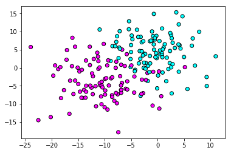

```python
from sklearn.datasets import make_blobs
import matplotlib.pyplot as plt

X, y=make_blobs(n_samples=200, random_state=1,centers=2,cluster_std=5)
plt.scatter(X[:,0],X[:,1],c=y, cmap=plt.cm.cool, edgecolor='k')
plt.show()
```

- 输出预测结果及分类概率

```python
from sklearn.naive_bayes import GaussianNB
X_train, X_test, y_train, y_test=train_test_split(X,y,random_state=68)
gnb = GaussianNB()
gnb.fit(X_train, y_train)
predict_proba = gnb.predict_proba(X_test)
print('预测准确率形态：{}'.format(predict_proba.shape))
```

```
预测准确率形态：(50, 2)
```

```python
print(predict_proba[:5])
```

```
[[ 0.98849996  0.01150004]
 [ 0.0495985   0.9504015 ]
 [ 0.01648034  0.98351966]
 [ 0.8168274   0.1831726 ]
 [ 0.00282471  0.99717529]]
```

- 可视化所有样本的概率

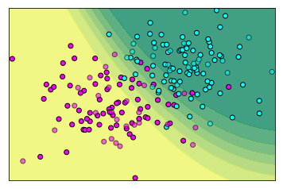

```python
x_min, x_max = X[:, 0].min() - .5, X[:, 0].max() + .5
y_min, y_max = X[:, 1].min() - .5, X[:, 1].max() + .5
xx, yy = np.meshgrid(np.arange(x_min, x_max, 0.2),
                         np.arange(y_min, y_max, 0.2))

Z = gnb.predict_proba(np.c_[xx.ravel(), yy.ravel()])[:, 1]
Z = Z.reshape(xx.shape)
plt.contourf(xx, yy, Z, cmap=plt.cm.summer, alpha=.8)

plt.scatter(X_train[:, 0], X_train[:, 1], c=y_train, cmap=plt.cm.cool,
                   edgecolor='k')
plt.scatter(X_test[:, 0], X_test[:, 1], c=y_test, cmap=plt.cm.cool,
                   edgecolor='k', alpha=0.6)

plt.xlim(xx.min(), xx.max())
plt.ylim(yy.min(), yy.max())
plt.xticks(())
plt.yticks(())
plt.show()
```

- 使用Decision_function决定系数来检查分类的可信度

在分类任务中，另外一个比较有用的函数是Decision_function()，用来衡量样本与分界面之间的距离。

```python
from sklearn.svm import SVC
svc = SVC(gamma="auto").fit(X_train, y_train)
dec_func = svc.decision_function(X_test)
print (dec_func[:5])
```

[output not shown]

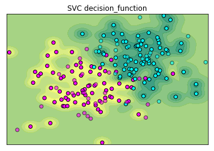

```python
Z = svc.decision_function(np.c_[xx.ravel(), yy.ravel()])
Z = Z.reshape(xx.shape)
plt.contourf(xx, yy, Z, cmap=plt.cm.summer, alpha=.8)

plt.scatter(X_train[:, 0], X_train[:, 1], c=y_train, cmap=plt.cm.cool,
                   edgecolor='k')
plt.scatter(X_test[:, 0], X_test[:, 1], c=y_test, cmap=plt.cm.cool,
                   edgecolor='k', alpha=0.6)

plt.xlim(xx.min(), xx.max())
plt.ylim(yy.min(), yy.max())
plt.title('SVC decision_function')
plt.xticks(())
plt.yticks(())
plt.show()
```

在可视化图中，不同的类别使用不同的颜色来区分，浅色为一类，深色为另一类，而那些处于颜色分界面上的样本就是那些摸棱两可的样本，也即概率接近0.5的样本。

**【本章小结】**

学习到这里，我们一致都在采用score来对模型进行评价，在分类任务中，它代表的是 **Accuracy精度** 这个评价指标；在回归任务中代表的是 **$R^2$可决系数**，即回归平方和 与 总变差 之间的商。在实际任务中还有许多很重要的评价指标，如精度（Precision），召回率（Recall），F1分数（F1-Score），ROC曲线（Receiver Operation Characteristic Curve），PR曲线（精度和召回率的相关曲线），AUC（Area Under Curve）等。在使用网格搜索的时候，我们也可以使用这些评价指标。例如使用SVM模型时，同时使用ROC曲线，可以表示为：

```
grid = GridSearchCV(SVM(), param_grid=param_grid, scoring='roc_auc')
```

值得注意的是，无论是模型评估还是参数调节都是数据科学家必备的知识之一。

- 对于模型评估，不同的指标适合不同的任务，选择什么样的指标需要根据任务的目录来决定。
- 对于（超）参数调节，几乎是所有模型都需要的，如何获得最优的超参数，直接关系到模型的性能与最终目标的成败。